# Loken_HW3

Hilary Dugan + Luke Loken

February 13, 2018

# Hilary’s answers

## Question 2

**Make a 500 m buffer of the 4 southern LTER lakes. Which buffers overlap?**

*Lakes Data*: https://lter.limnology.wisc.edu/dataset/north-temperate-lakes-lter-yahara-lakes-district-boundary

```r
library(sp)
library(rgdal)
library(raster)
library(sf)
library(tidyr)
library(dplyr)
Lakes_sp <- readOGR(paste0("E:/Git_Repo/ZOO955/Data/Shapefiles"), "yld_study_lakes", stringsAsFactors = F)
Lakes_sf <- st_read("E:/Git_Repo/ZOO955/Data/Shapefiles/yld_study_lakes.shp", stringsAsFactors = F)
```

```r
#Make individual lake objects
ME <- Lakes_sf %>% filter(LAKEID == 'ME')
MO <- Lakes_sf %>% filter(LAKEID == 'MO')
WI <- Lakes_sf %>% filter(LAKEID == 'WI')
FI <- Lakes_sf %>% filter(LAKEID == 'FI')

#Transform to lat/long for axes plotting
Lakes_sf_latlong <- st_transform(Lakes_sf, crs=4326)

#Merging Hilary's and Luke's objects
lakes <- Lakes_sf

# What are the lake IDs?
ids <- lakes$LAKEID
names <- lakes$LAKE_NAME
```

Make 500 m buffer

```r
buffer500 = st_buffer(lakes,500)
#Check if buffers overlap
st_overlaps(buffer500)
```

```
## Sparse geometry binary predicate list of length 4, where the predicate was `overlaps'
##  1: (empty)
##  2: 3
##  3: 2, 4
##  4: 3
```

We know the order of the lake IDS (FI, ME, MO, WI). So based on the overlap matrix.

- Mendota overlaps with Monona.
- Monona overlaps with Mendota and Wingra
- Wingra overlaps with Monona

**Or we can add lake ids to table**

```r
# Repeat with sparse=False
overlaps <- st_overlaps(buffer500, sparse = FALSE)
colnames(overlaps) <- ids
rownames(overlaps) <- ids
print(overlaps)
```

```
##       FI    ME    MO    WI
## FI FALSE FALSE FALSE FALSE
## ME FALSE FALSE  TRUE FALSE
## MO FALSE  TRUE FALSE  TRUE
## WI FALSE FALSE  TRUE FALSE
```

## Question 3

**Increase the size of the lakes by 2x. What is the percent of Mendota that overlaps with Monona?**

Note:

- You can’t use a buffer because that does not retain the shape of the lakes.
- You can’t just multiply the lakes x2, because that multiplies the coordinates. You end up with the lakes somewhere other than Wisconsin.

Instead:

- Find the distance from the edge of the lake to the centroid. Multiply these distances by 2.

```r
# Take just the geometry of the lakes
glakes = st_geometry(lakes)
# Find the centroid
cntrd = st_centroid(glakes)

# Find distance from edge of lakes to centroid
cDist = (glakes - cntrd)
# Multiply this distance by 2 and add back to centroid
glakes2 = cDist * 2 + cntrd

# Find the intersection between Mendota and Monona. We know these are lakes 2 and 3.
int = st_intersection(glakes2[2],glakes2[3])
# What is the size difference between the intersection and Mendota
st_area(int)/ st_area(glakes2[2])
```

```
## [1] 0.1942473
```

**The percent of Mendota that overlaps with Monona is 19.4%**

If you want to double check by plotting

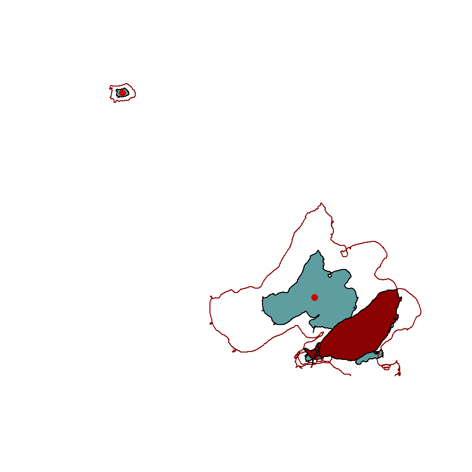

```r
# Plot glakes and centroid
plot(glakes,col='cadetblue')
plot(cntrd,col='red3',pch=16,add=T)
# Plot lakes double the size
plot(glakes2,border='red4',add=T)
# Plot intersection
plot(int,col='red4',add=T)
```

Dear Dr. Dugan:

## Question 1: What does `st_buffer` do?

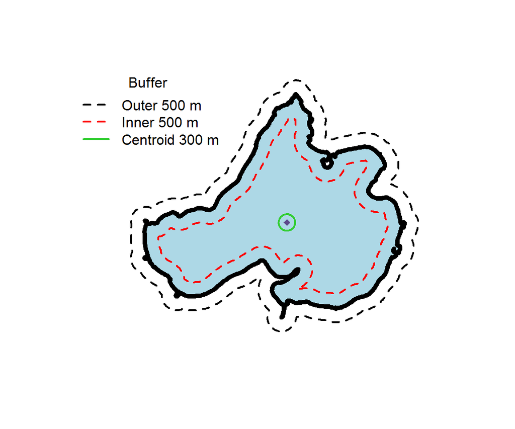

`st_buffer` creates a new polygon that all points are X distance away from the edge of another polygon, line or point. The buffer can extend outward (+) or inward (-) of a polygon.

## Question 2: Make a 500 m buffer around the 4 southern LTER lakes, which buffers overlap?

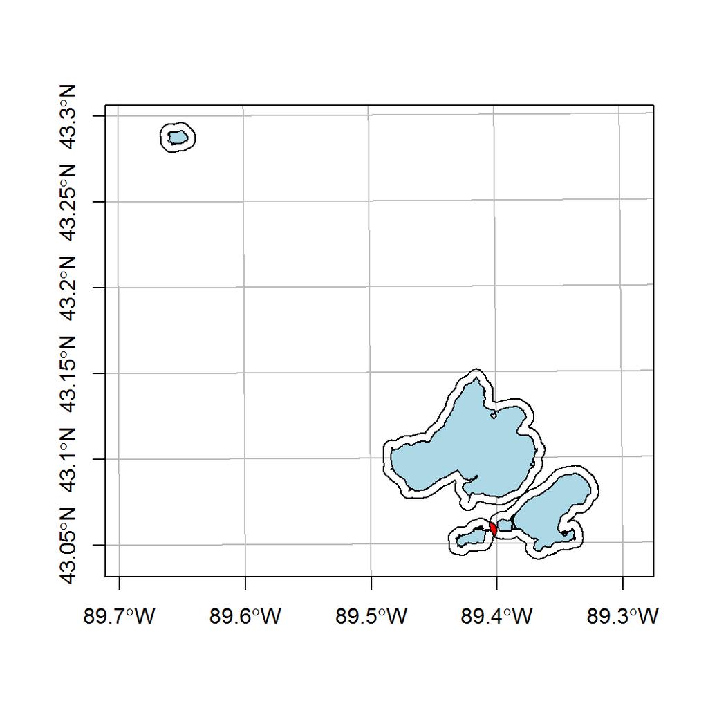

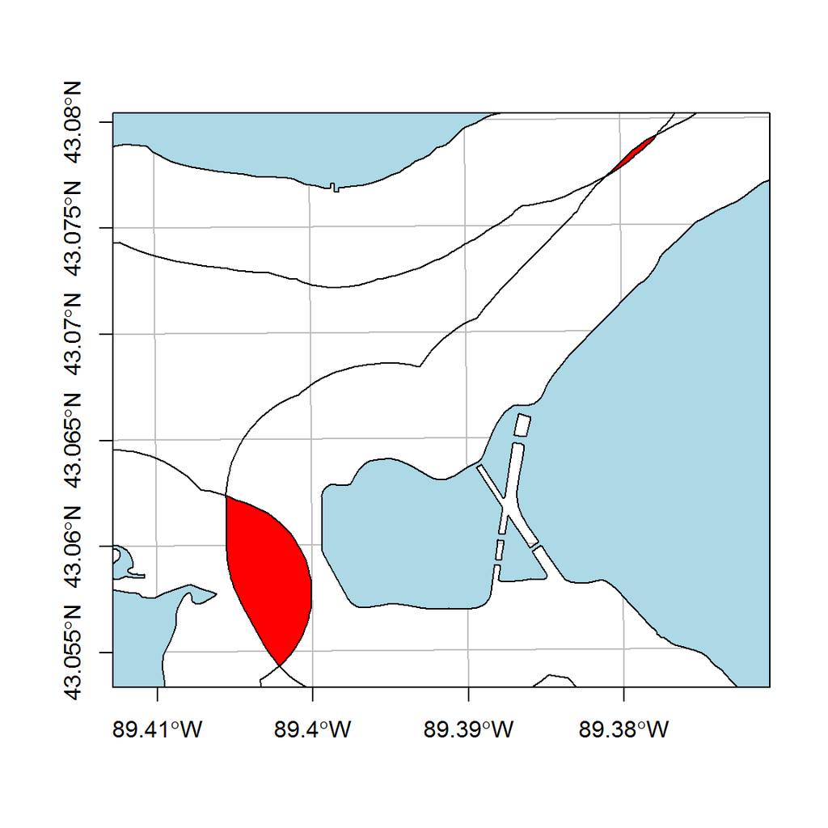

Based on `st_overlaps`, the buffer around Lake Monona (ID#3) overlaps both the Lake Mendota (ID#2) and Lake Wingra (ID#4) buffers. No other polygons overlap.

```r
overlaps<-st_overlaps(Lakes_sf500)
names(overlaps)<-Lakes_sf500$LAKE_NAME
str(overlaps)
```

```
## List of 4
##  $ Fish Lake   : int(0)
##  $ Lake Mendota: int 3
##  $ Lake Monona : int [1:2] 2 4
##  $ Lake Wingra : int 3
##  - attr(*, "predicate")= chr "overlaps"
##  - attr(*, "region.id")= chr [1:4] "1" "2" "3" "4"
##  - attr(*, "ncol")= int 4
##  - attr(*, "class")= chr "sgbp"
```

## Question 3: Increase the size of the lakes by 2x, What percent of Mendota overlaps with Monona?

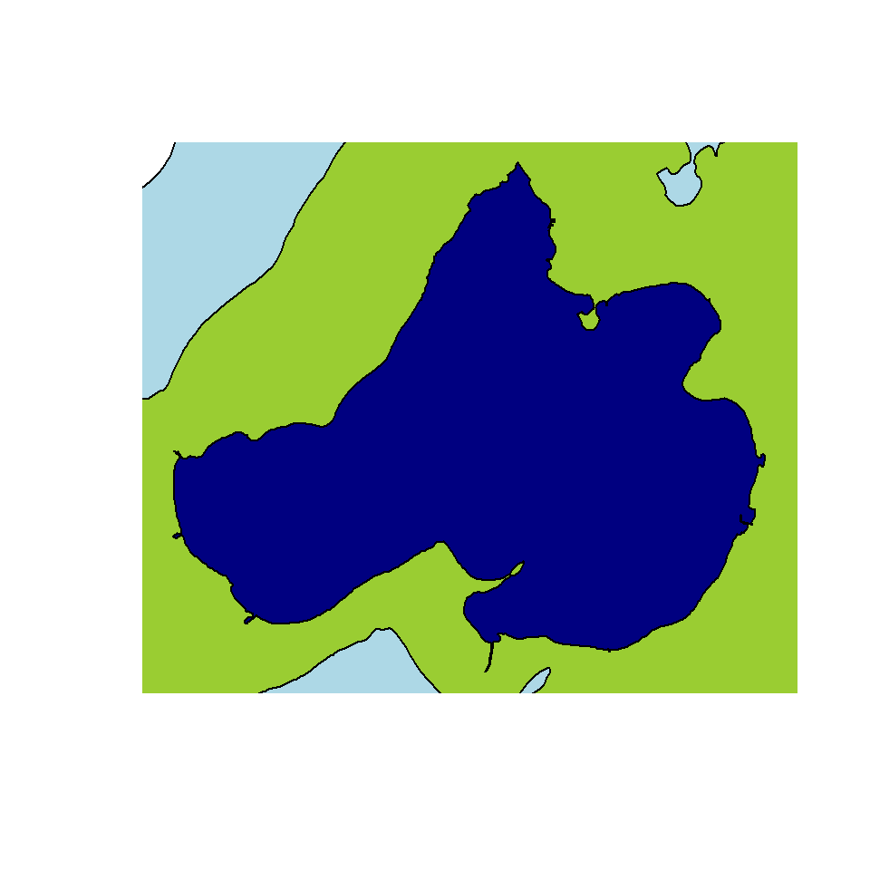

```r
ME_centroid<-st_centroid(ME)
ME_points<-st_cast(ME, "POINT")

x<-st_coordinates(ME_points)[,1]
y<-st_coordinates(ME_points)[,2]

x2<-2*x-st_coordinates(ME_centroid)[,1]
y2<-2*y-st_coordinates(ME_centroid)[,2]

ME_points2<-st_multipoint(as.matrix(data.frame(x2, y2)))
ME_points3<-st_sfc(ME_points2)

ME_Lines<-st_multilinestring(ME_points3)
ME_Polygon<-st_polygonize(ME_Lines)

ME_Polygon2<-st_geometry(ME_Polygon, type = 3)
st_crs(ME_Polygon2) <- st_crs(ME)
overlap<-st_intersection(ME_Polygon2, MO)

# Another way to override X and Y coordinates of Lake Mendota
# Can only do this on a single polygon feature (i.e., not all the lakes at once)
ME2<-ME
ME3<-ME

#Pull coordinates and put in vectors
x<-st_coordinates(ME)[,1]
y<-st_coordinates(ME)[,2]

#Calculate new coordinates in vectors
x2<-2*x-st_coordinates(ME_centroid)[,1]
y2<-2*y-st_coordinates(ME_centroid)[,2]

#Triple size of Lake Mendota
x3<-st_coordinates(ME_centroid)[,1]+(x-st_coordinates(ME_centroid)[,1])*3
y3<-st_coordinates(ME_centroid)[,2]+(y-st_coordinates(ME_centroid)[,2])*3

#Replace existing geometries on Polygon feature
#Careful this will edit the points of an existing feature. Similar to 'edit' in ESRI.
#Note this does not change the bbox, area, perimeter, or other attributes associated with the feature.
ME2$geometry[[1]][[1]][,1]<-x2
ME2$geometry[[1]][[1]][,2]<-y2

ME3$geometry[[1]][[1]][,1]<-x3
ME3$geometry[[1]][[1]][,2]<-y3

#Hence plotting window is messed up.
plot(ME3$geometry, col='lightblue')
plot(ME2$geometry, add=T, col='yellowgreen')
plot(ME$geometry, add=T, col='navy')
```

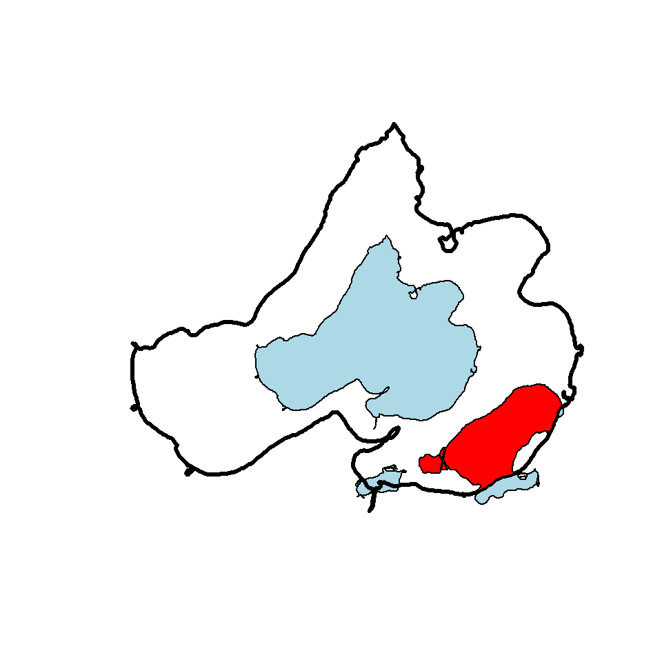

```r
plot(ME_Polygon, col=NA, lwd=3)
plot(Lakes_sf$geometry, col='lightblue', add=T)
plot(ME_Polygon, col=NA, lwd=3, add=T)
plot(overlap, add=T, col='red')
```

```r
overlap_area<-st_area(overlap)
BigMendota_area<-st_area(ME_Polygon2)
as.numeric(overlap_area/BigMendota_area)
```

```
## [1] 0.07484969
```

# More code to work through question 3

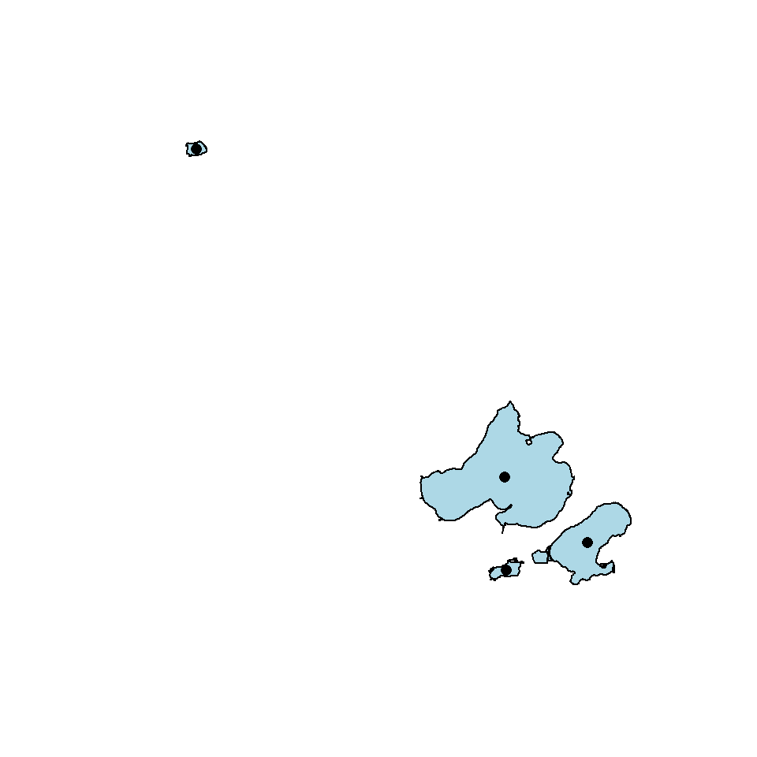

```r
# Take just the geometry of the lakes
glakes = st_geometry(lakes)
# Find the centroid
cntrd = st_centroid(glakes)

plot(glakes, col='lightblue')
plot(cntrd, add=T, pch=16)
```

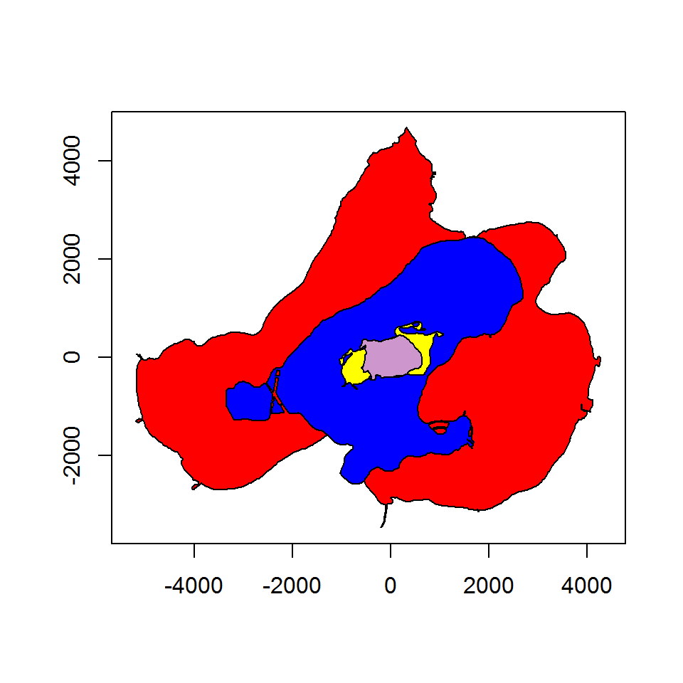

```r
# Find distance from edge of lakes to centroid
cDist = (glakes - cntrd)
plot(cDist[c(2,3,4,1)], col=c('red', 'blue', 'yellow', 'plum3'), axes=T)
```

```r
# Multiply this distance by 2 and add back to centroid
glakes2 = cDist * 2 + cntrd

# Find the intersection between Mendota and Monona. We know these are lakes 2 and 3.
int = st_intersection(glakes2[2],glakes2[3])
# What is the size difference between the intersection and Mendota
st_area(int)/ st_area(glakes2[2])
```

```
## [1] 0.1942473
```

## Another way to do it, without creating a ‘distance’ polygon

```r
# using geometry you can simply double the coordinates and subtract by the centroid
glakes3 = glakes*2 - cntrd

int = st_intersection(glakes3[2],glakes3[3])

st_area(int)/ st_area(glakes3[2])
```

```
## [1] 0.1942473
```

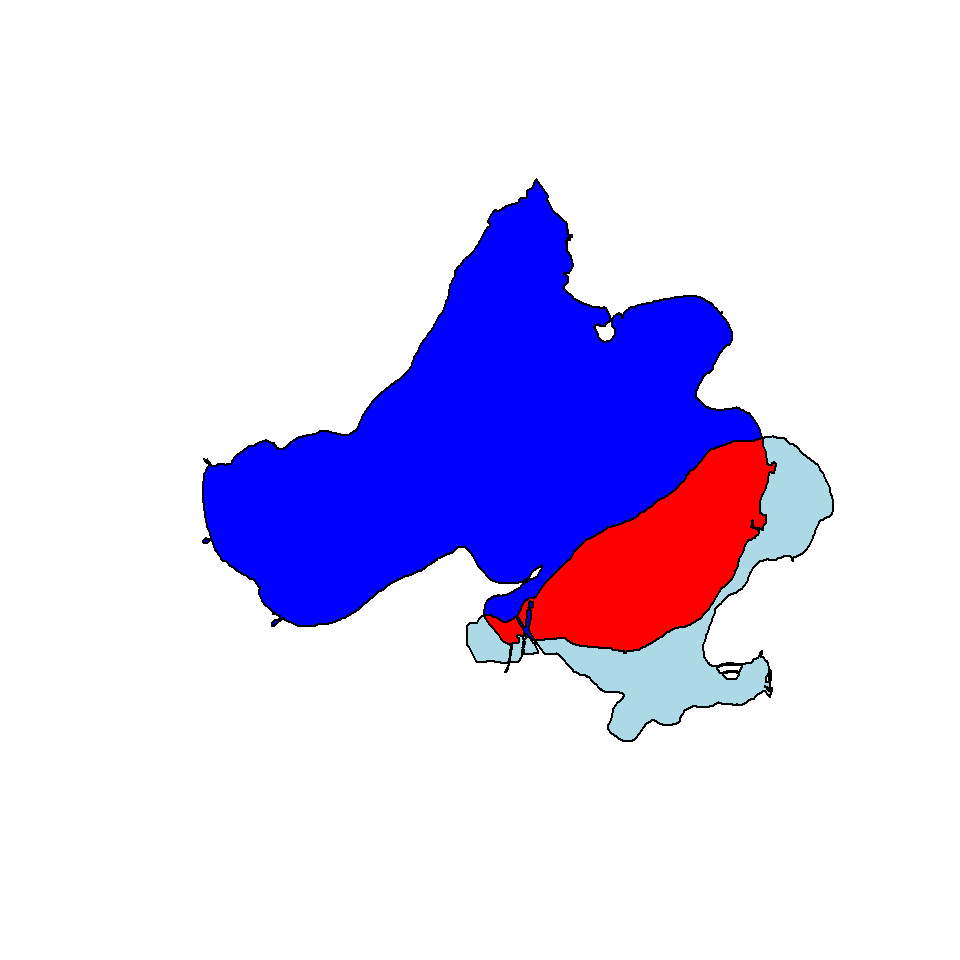

```r
plot(glakes3[2:3], col=c('blue', 'lightblue'))
plot(int, col=c('red'), add=T)
```

This does not work if you use the sf object. This code creates an error

`lakes3 <- lakes*2 - st_centroid(lakes)`

But if you use the `st_geometry` function you can do geometry math

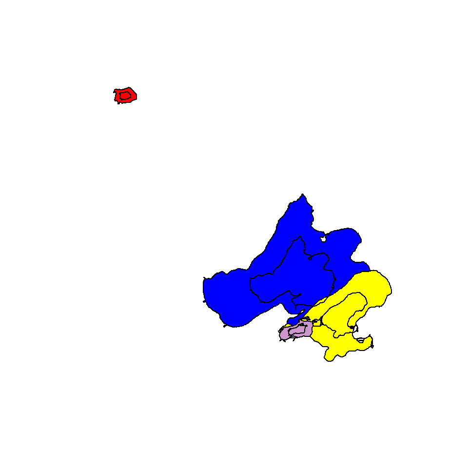

```r
biglakes <- st_geometry(lakes)*2 - st_centroid(st_geometry(lakes))
plot(biglakes, col=c('red', 'blue', 'yellow', 'plum3'))
plot(lakes, add=T, col=NA)
```

## Look at difference between objects

```r
class(lakes)
```

```
## [1] "sf"         "data.frame"
```

```r
lakes
```

```
## Simple feature collection with 4 features and 9 fields
## geometry type:  POLYGON
## dimension:      XY
## bbox:           xmin: 547589.4 ymin: 286020.8 xmax: 574950 ymax: 313254
## epsg (SRID):    NA
## proj4string:    +proj=tmerc +lat_0=0 +lon_0=-90 +k=0.9996 +x_0=520000 +y_0=-4480000 +ellps=GRS80 +towgs84=0,0,0,0,0,0,0 +units=m +no_defs
##         AREA PERIMETER SHAID_ SHAID_ID SHAID_NO    SHAIDNAME LAKEID
## 1   803713.3  4062.712  72988    73642 10004757    Fish Lake     FI
## 2 39582017.4 38416.498  75771    76455  8000298 Lake Mendota     ME
## 3 13587633.0 26452.918  76305    77023  8000394  Lake Monona     MO
## 4  1360882.9  8804.314  76422    77140  8000429  Lake Wingra     WI
##      LAKE_NAME   WBIC                       geometry
## 1    Fish Lake 985100 POLYGON ((547659.4 312505.9...
## 2 Lake Mendota 805400 POLYGON ((570841.6 293544.9...
## 3  Lake Monona 804600 POLYGON ((570670 287180.7, ...
## 4  Lake Wingra 805000 POLYGON ((566875.8 286473.8...
```

```r
str(lakes)
```

```
## Classes 'sf' and 'data.frame':   4 obs. of  10 variables:
##  $ AREA     : num  803713 39582017 13587633 1360883
##  $ PERIMETER: num  4063 38416 26453 8804
##  $ SHAID_   : int  72988 75771 76305 76422
##  $ SHAID_ID : int  73642 76455 77023 77140
##  $ SHAID_NO : int  10004757 8000298 8000394 8000429
##  $ SHAIDNAME: chr  "Fish Lake" "Lake Mendota" "Lake Monona" "Lake Wingra"
##  $ LAKEID   : chr  "FI" "ME" "MO" "WI"
##  $ LAKE_NAME: chr  "Fish Lake" "Lake Mendota" "Lake Monona" "Lake Wingra"
##  $ WBIC     : int  985100 805400 804600 805000
##  $ geometry :sfc_POLYGON of length 4; first list element: List of 1
##   ..$ : num [1:177, 1:2] 547659 547658 547659 547658 547650 ...
##   ..- attr(*, "class")= chr  "XY" "POLYGON" "sfg"
##  - attr(*, "sf_column")= chr "geometry"
##  - attr(*, "agr")= Factor w/ 3 levels "constant","aggregate",..: NA NA NA NA NA NA NA NA NA
##   ..- attr(*, "names")= chr  "AREA" "PERIMETER" "SHAID_" "SHAID_ID" ...
```

```r
class(glakes)
```

```
## [1] "sfc_POLYGON" "sfc"
```

```r
glakes
```

```
## Geometry set for 4 features
## geometry type:  POLYGON
## dimension:      XY
## bbox:           xmin: 547589.4 ymin: 286020.8 xmax: 574950 ymax: 313254
## epsg (SRID):    NA
## proj4string:    +proj=tmerc +lat_0=0 +lon_0=-90 +k=0.9996 +x_0=520000 +y_0=-4480000 +ellps=GRS80 +towgs84=0,0,0,0,0,0,0 +units=m +no_defs
```

```
## POLYGON ((547659.4 312505.9, 547657.6 312513.8,...
```

```
## POLYGON ((570841.6 293544.9, 570862.1 293540.3,...
```

```
## POLYGON ((570670 287180.7, 570662.8 287187.2, 5...
```

```
## POLYGON ((566875.8 286473.8, 566869.4 286473.7,...
```

```r
str(glakes)
```

```
## sfc_POLYGON of length 4; first list element: List of 1
##  $ : num [1:177, 1:2] 547659 547658 547659 547658 547650 ...
##  - attr(*, "class")= chr [1:3] "XY" "POLYGON" "sfg"
```